# A Project Report On Hotel Booking Company

Shuvam Anupam

2024-02-22

# Scenario

In this analysis of the Hotel booking Company, diffrent types of visualizations were shown on the demand of the stackholders.

Loading the dataset assigning a dataframe

```r
hotel_bookings_df <- read_csv("hotel_bookings.csv")
```

Data Preview

```r
head(hotel_bookings_df)
```

```
## # A tibble: 6 × 32
##   hotel        is_canceled lead_time arrival_date_year arrival_date_month
##   <chr>              <dbl>     <dbl>             <dbl> <chr>
## 1 Resort Hotel           0       342              2015 July
## 2 Resort Hotel           0       737              2015 July
## 3 Resort Hotel           0         7              2015 July
## 4 Resort Hotel           0        13              2015 July
## 5 Resort Hotel           0        14              2015 July
## 6 Resort Hotel           0        14              2015 July
## # ℹ 27 more variables: arrival_date_week_number <dbl>,
## #   arrival_date_day_of_month <dbl>, stays_in_weekend_nights <dbl>,
## #   stays_in_week_nights <dbl>, adults <dbl>, children <dbl>, babies <dbl>,
## #   meal <chr>, country <chr>, market_segment <chr>,
## #   distribution_channel <chr>, is_repeated_guest <dbl>,
## #   previous_cancellations <dbl>, previous_bookings_not_canceled <dbl>,
## #   reserved_room_type <chr>, assigned_room_type <chr>, …
```

```r
colnames(hotel_bookings_df)
```

```
##  [1] "hotel"                          "is_canceled"
##  [3] "lead_time"                      "arrival_date_year"
##  [5] "arrival_date_month"             "arrival_date_week_number"
##  [7] "arrival_date_day_of_month"      "stays_in_weekend_nights"
##  [9] "stays_in_week_nights"           "adults"
## [11] "children"                       "babies"
## [13] "meal"                           "country"
## [15] "market_segment"                 "distribution_channel"
## [17] "is_repeated_guest"              "previous_cancellations"
## [19] "previous_bookings_not_canceled" "reserved_room_type"
## [21] "assigned_room_type"             "booking_changes"
## [23] "deposit_type"                   "agent"
## [25] "company"                        "days_in_waiting_list"
## [27] "customer_type"                  "adr"
## [29] "required_car_parking_spaces"    "total_of_special_requests"
## [31] "reservation_status"             "reservation_status_date"
```

Data Cleaning Removing missing values from the data

```r
na.omit(hotel_bookings_df)
```

```
## # A tibble: 119,386 × 32
##    hotel        is_canceled lead_time arrival_date_year arrival_date_month
##    <chr>              <dbl>     <dbl>             <dbl> <chr>
##  1 Resort Hotel           0       342              2015 July
##  2 Resort Hotel           0       737              2015 July
##  3 Resort Hotel           0         7              2015 July
##  4 Resort Hotel           0        13              2015 July
##  5 Resort Hotel           0        14              2015 July
##  6 Resort Hotel           0        14              2015 July
##  7 Resort Hotel           0         0              2015 July
##  8 Resort Hotel           0         9              2015 July
##  9 Resort Hotel           1        85              2015 July
## 10 Resort Hotel           1        75              2015 July
## # ℹ 119,376 more rows
## # ℹ 27 more variables: arrival_date_week_number <dbl>,
## #   arrival_date_day_of_month <dbl>, stays_in_weekend_nights <dbl>,
## #   stays_in_week_nights <dbl>, adults <dbl>, children <dbl>, babies <dbl>,
## #   meal <chr>, country <chr>, market_segment <chr>,
## #   distribution_channel <chr>, is_repeated_guest <dbl>,
## #   previous_cancellations <dbl>, previous_bookings_not_canceled <dbl>, …
```

Used ‘geom_point’ to make a scatter plot comparing lead_time and number of children in this code chunk: On the x-axis, the plot shows how far in advance a booking is made, with the bookings furthest to the right happening the most in advance. On the y-axis it shows how many children there are in a party.

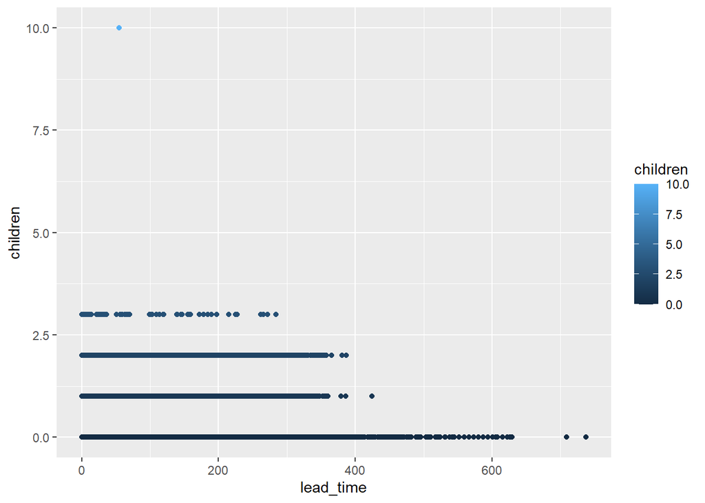

```r
ggplot(data = hotel_bookings_df) +
  geom_point(mapping = aes(x=lead_time,y=children, color= children))
```

Company wants to increase weekend bookings, an important source of revenue for the hotel. Company wants to know what group of guests book the most weekend nights in order to target that group in a new marketing campaign.

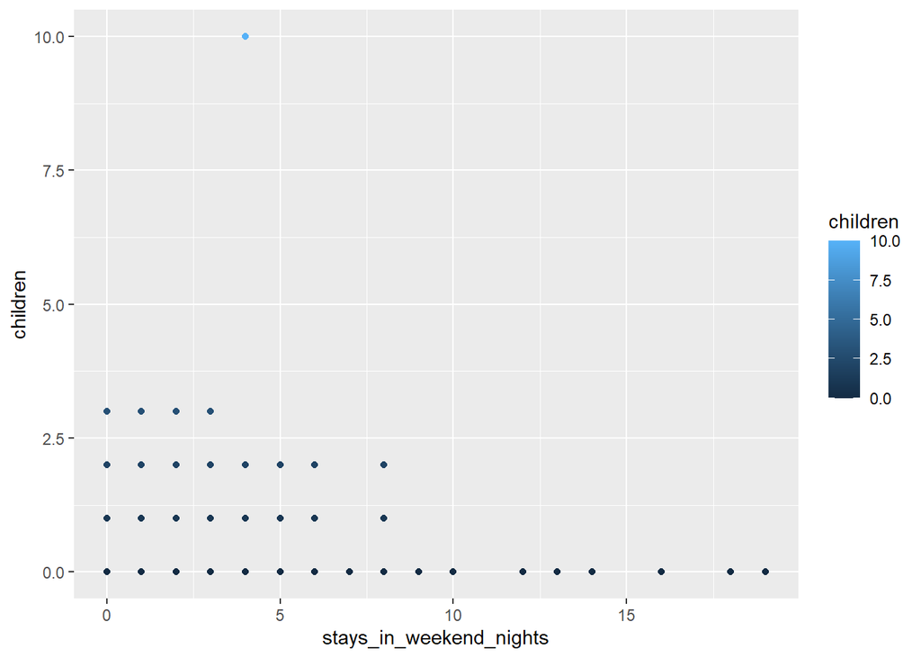

```r
ggplot(data = hotel_bookings_df)+
  geom_point(mapping = aes(x=stays_in_weekend_nights, y=children,color = children))
```

Used ‘geom_bar’ to show how many transactions are occurring for each different distribution type.This code chunk creates a bar chart with ‘distribution_channel’ on the x axis and ‘count’ on the y axis. There is data for corporate, direct, GDS, TA/TO, and undefined distribution channels. It also includes data from ‘deposit_type’ column as color-coded sections of each bar. There is a legend explaining what each color represents on the right side of the visualization.

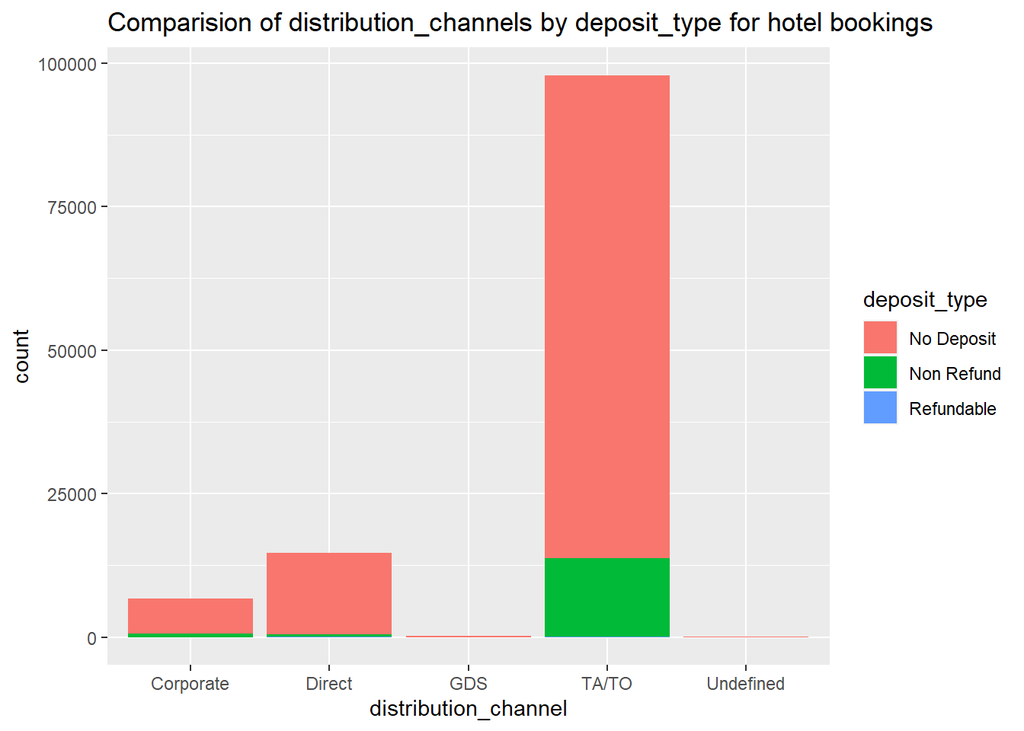

```r
ggplot(data = hotel_bookings_df) +
  geom_bar(mapping = aes(x= distribution_channel,fill = deposit_type))+
  labs(title ="Comparision of distribution_channels by deposit_type for hotel bookings")
```

This bar chart is similar to the previous chart, except that ‘market_segment’ data is being recorded in the color-coded sections of each bar.

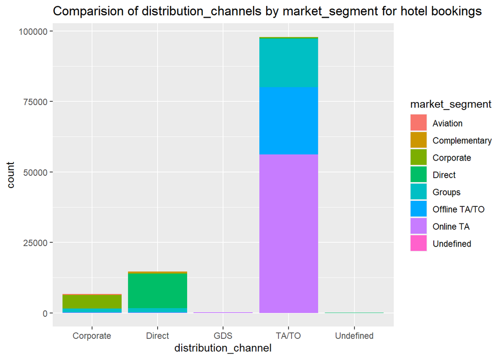

```r
ggplot(data = hotel_bookings_df) +
  geom_bar(mapping = aes(x= distribution_channel, fill = market_segment))+
  labs(title ="Comparision of distribution_channels by market_segment for hotel bookings")
```

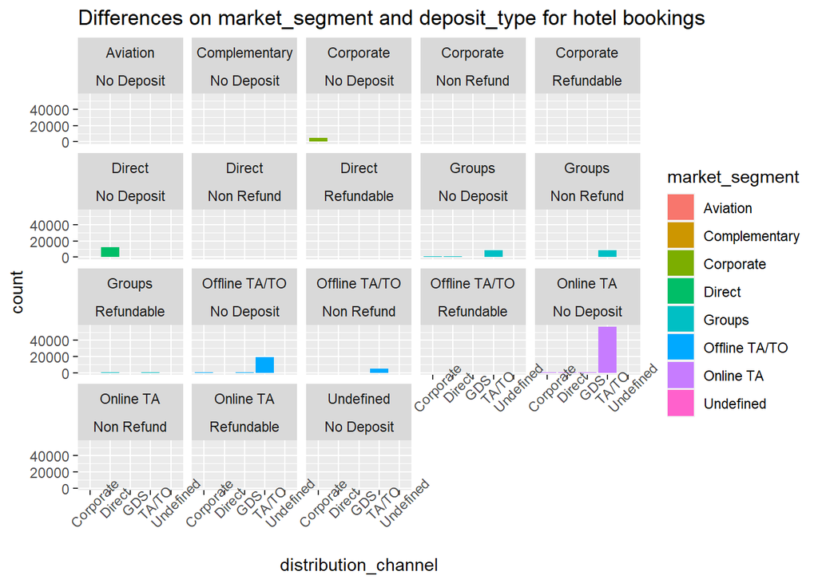

```r
ggplot(data = hotel_bookings_df) +
  geom_bar(mapping = aes(x=distribution_channel,fill= market_segment)) +
  facet_wrap(~market_segment~deposit_type) +
  theme(axis.text.x = element_text(angle = 45))+
  labs(title ="Differences on market_segment and deposit_type for hotel bookings")
```

# Conclusion

By the visualizations shown above will help the stackholders to gain insights on hotel booking strategy on different scenarios.

```
                                         ***End of the Report***
```